# Mozambique Riots/Protests

# Question:

Will ACLED record any riot/protest events in Mozambique in October 2017?

# Description:

The Armed Conflict Location and Event Dataset (ACLED) summarizes press reports on conflict and protest events in Africa and parts of Asia. Outcome will be determined by the “Realtime [Month of Interest] All Africa File” found on the Realtime Data page (ACLED). The question will resolve as “yes” if ACLED records any event for which: ‘COUNTRY’ is the country of interest; ‘EVENT_DATE’ falls in the period of interest; and ‘EVENT_TYPE’ is ‘Riots/Protests’. The question will be resolved when the relevant data is first released.

# Code

Import libraries and ACLED dataset

```r
library(XLConnect)
library(XLConnect)
library(lubridate)
```

Subset to relevant Mozambique data and convert EVENT_TYPE to character

```r
moz_data[] <- lapply(moz_data$EVENT_TYPE, as.character)
```

[output not shown]

Create a date variable consistent with a normal R date

```r
kenya_data$DATE <- as.Date(kenya_data$EVENT_DATE, format = "%d/%m/%Y")
```

[output not shown]

Create a vector of every day from 1/1/2007 to 12/31/2016

Merge the two datasets and a flag for dates on which a riot or protest occurred

```r
daily_data <- merge(x = full_range, y = moz_data, by = "DATE", all.x = TRUE)
```

[output not shown]

Aggregate the data by day

Plot the days with events

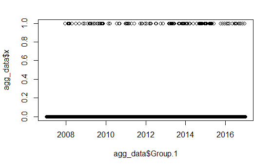

## Daily likelihood

Find the daily likelihood of an event

```r
daily_likelihood
```

```
[1] 0.03859841
```

So, on any given day there is roughly a 3.9% chance that a protest or riot will occur.

Find the number of days in October

```r
num_days <- as.numeric(end_date) - as.numeric(current_date) + 1
```

[output not shown]

Calculate the likelihood of an event in the month of October

```r
1 - (1 - daily_likelihood)**num_days
```

```
[1] 0.7048452
```

## Monthly likelihood

Aggregate the data by month

Calculate monthly likelihood

```r
monthly_likelihood
```

```
[1] 0.5916667
```

Use the average of these likelihoods

```r
((1 - (1 - daily_likelihood)**num_days) + monthly_likelihood)/2
```

```
[1] 0.6482559
```